# Project 6: Linked Labyrinths

Adopted from Nifty Assignment: Linked List Labyrinth by Keith Schwarz

Author

Jed Rembold

Published

August 16, 2024

In this short project you’ll practice using and analyzing pre-built linked lists to navigate your way through a virtual maze. Along the way you’ll be experience traversing linked lists, as well as utilizing modern debuggers to investigate complicated data structures.

As per usual, you will submit this project through GitHub Classroom, and you can find the link to accept the project and download the initial template files below.

[Accept Project](https://classroom.github.com/a/YQ2_e1kF)

# Introduction

You have been trapped in a labyrinth, and your only hope to escape is to cast the magic spell that will free you from its walls. To do so, you will need to first explore the labyrinth to find three magical items:

- The *Spellbook* (📖), which contains the spell you need to cast to escape,
- The *Potion* (🧪), containing the arcane compounds to power the spell,
- and The *Wand* (☨), which concentrates your focus to make the spell work.

Once you have gathered all three items, you can cast the spell to escape to safety.

This is, of course, no ordinary maze. It is a **reference maze**. The maze consists of a collection of cell objects of type `MazeCell`. Each cell has the following properties defined:

- `contents`: what item is present in that cell. Only a single item will ever be in a given cell. Is `None` if no item is present.
- `north`: what cell is to the North of this cell (`None` if no cell this direction)
- `south`: what cell is to the South of this cell (`None` if no cell this direction)
- `east`: what cell is to the East of the cell (`None` if no cell this direction)
- `west`: what cell is to the West of the cell (`None` if no cell this direction)

For example, below is a $4\times 4$ labyrinth. We have marked your starting position with a smiley face and the positions of the three items with the above shown emojis. The `MazeCell` you begin at would have its `north`, `south`, `east`, and `west` properties referencing the `MazeCell` objects located one step in each of those directions from you. On the other hand, the `MazeCell` containing the spellbook would have its north, east, and west properties set to `None`, and only its south property would point somewhere (specifically, to the `MazeCell` corresponding to the bottom left corner).

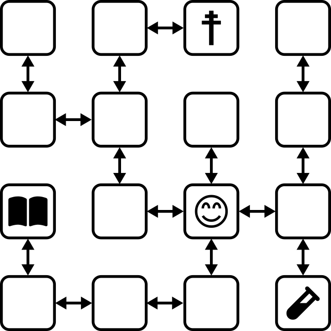

Each `MazeCell` has a property `contents` that indicates what item, if any, is at that position. Empty cells will have `contents` set to `None`. The cells containing the spellbook, potion, or wand will have those fields set to `Item.SPELL`, `Item.POTION`, or `Item.WAND`, respectively, though you likely will not need to interact with them much directly.

If you were to find yourself in this labyrinth, you could walk around a bit to find the items you need to cast the escape spell. There are many paths you can take; here are three of them:

`ESNWWNNEWSSESWWN`

`SWWNSEENWNNEWSSEES`

`WNNEWSSESWWNSEENES`

Each path is represented as a sequence of letters (`N` for North, `W` for West, etc.) that, when followed from left to right, trace out the directions you’d follow. For example, the first sequences represents going east, then south (getting the Potion), then north, then west, etc. Trace through those paths and make sure you see how they pick up all three items.

# Milestones

There are three parts of this project, though only the first really requires any coding. They are each explained below.

## Milestone 1: Checking Paths to Freedom

Your first task is to write a function that, given a cell in a maze and a path, checks whether that path is legal and picks up all three items. Specifically, in the file `linked_labyrinth.py`, implement the function `is_path_to_freedom`. This function takes as input your starting location in the maze (as a `MazeCell` obj) and a string made purely from the characters `"N"`, `"S"`, `"E"`, and `"W"`, then returns whether that path lets you escape from the maze.

A path lets you escape from the maze if:

1. The path is legal, in the sense that it never tries to take a step that isn’t permitted in the current `MazeCell` (no running into walls here!)
2. The path pass through the cells containing the Spellbook, the Wand, and the Potion. The order in which those items are picked up is irrelevant, and it is ok if the path continues onward after picking all of the items up.

You can assume that the `start` parameter is a valid `MazeCell` and that the input string only has valid characters.

To summarize, you need to:

- Implement the `is_path_to_freedom` function
- Test your code thoroughly using the provided tests! If you’d like to write your own tests, you certainly can, but it is not required. Make sure all tests are passing before continuing onward!

**Note**

Some notes on this problem:

- Your code should work for a `MazeCell` from any possible maze, not just the example maze shown above.
- Although the example maze was structured so that if there was a link from one cell to another going North, there would always be a link from the second cell back to the first going South (and the same for East/West links), you should *not* assume this is the case in this function. Though chances are that you wouldn’t need to assume this.
- A path might visit the same location multiple times, including possibly visiting locations with items in them multiple times.
- You should not need to create any new `MazeCell` objects in the course of solving this problem. You can certainly define variables that point to a given `MazeCell`, but no new cells should be created. (After all, you are trying to escape, not expand your maze!)
- Your code should not modify the maze passed into the function. In particular, you should not change which items appear where or where the references point.
- A potential edge case that you should handle: it is okay to find all three items and then continue to walk around the maze. However, if the path finds all three items and then tries making an illegal step, then your function should return `False`

## Milestone 2: Escape!

Your next task is to escape from a maze that has been specifically constructed for you. In `linked_labyrinth.py`, you may notice a constant titled `NAME` near the top. Entering in your name as a string to this variable will ensure that you get a personalized maze created from which you can try to escape. Your job is to figure out a path through the labyrinth that picks up all three items, allowing you to escape.

Now notice the function `gridded` in `linked_labyrinth` that has already been defined for you. This function uses your provided `NAME` to construct a personalized maze, and then uses your earlier defined function to check to see if the parameter `path_out` is a valid solution to that maze. Initially, you will have no idea what `path_out` needs to be to escape, but once you work out the proper path you can update this to unsure that your path is valid!

To come up with a path out of the maze, use the debugger! Set a breakpoint at the indicated line inside the `gridded` function and ensure the `gridded` function call is uncommented down in the `if __name__ == "__main__":` block. Now run your program in debugging mode as we demonstrated in class. When you do, on the left side of the screen you’ll see the local variables pop up, one of which will be named `start` and represent the starting `MazeCell`. Clicking the dropdown triangle in the debugger window next to `start` will let you see all the properties of that particular `MazeCell`, including the `contents` and various directional paths.

Depending on your maze, you may find yourself in a position where you can move in all four directions, or you may find that you can only move in some of them. The properties in directions you can’t go are all equal to `None`. The properties that indicate directions that you can go will indicate that they point to another `MazeCell`, and thus will have another dropdown triangle next to them. Clicking these arrows will show you the `MazeCell`s reachable by moving in the indicated directions. You can navigate the maze further by choosing one of those dropdown arrows, or you could back up to the starting maze cell and explore in other directions. It is up to you!

Grab a sheet of paper, because you are almost certainly going to need to map this out. There is no guarantee where you begin in the maze, and the items are scattered randomly, so you’ll need to seek them out. This maze is on a perfect grid, so you can use the directions to map out the cells and determine how far you need to travel in different directions to find the necessary items. Once you have gone through and mapped the maze out, construct and escape sequence and enter it in as the argument to `gridded` at the bottom of the file. If you run the program again once properly setting that value, you should see a congratulatory message if you got it correct! If you are still trapped, you have some options. You could step through your path by moving a breakpoint up inside your `is_path_to_freedom` function to see if one of the letters you entered isn’t what you intended and accidentally tries to move in an illegal direction. Or perhaps the issue is that you misdrew your map, and you have ended up somewhere without all the items. You could try exploring the maze again in the debugger to see if you mislabeled or drew something incorrectly.

Once you have established a valid path to escape your personal maze, and confirm it works, you are free to continue on to Milestone 3.

## Milestone 3: Twisted Escape

Now let’s make things a bit more interesting. In the previous section, you escaped from a labyrinth that nicely obeyed the laws of geometry. The locations you visited formed a nice grid, where any time you went north, you could then go back south to get back to where you started (and similarly for east and west). In this milestone we are going to relax those constraints, and you’ll need to find your way out of a trickier maze that look more similar to the one shown below.

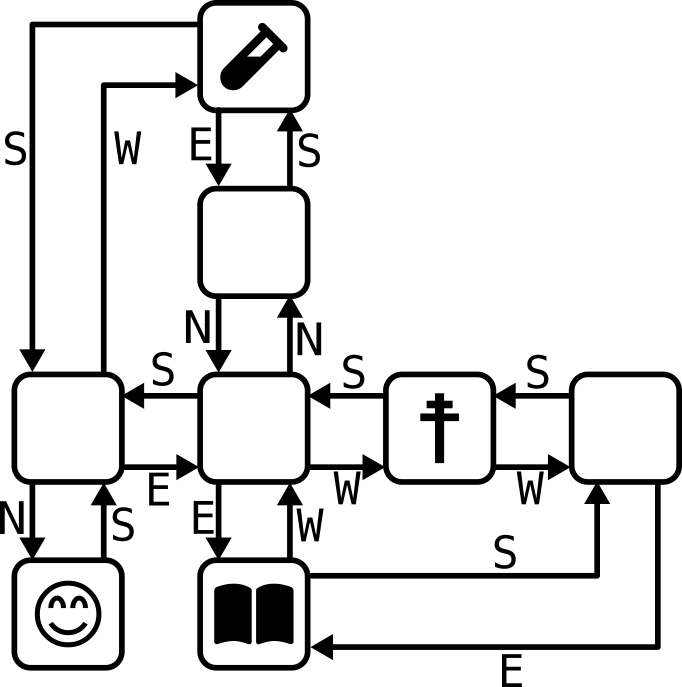

This maze is strangcer than the previous one you explored. For example, you’ll notice that these `MazeCell`s are no longer in a nice rectangular grid where directions of motion correspond to the natural cardinal directions. There is a `MazeCell` here where moving North and then North again will take you back to where you started! In one spot, if you move West, you have to move *South* to return to where you used to be. In that sense, the names “North”, “South”, “East” and “West” here no longer have any nice geometric meaning: they are just names of four possible exits from one `MazeCell` into another. The one guarantee you do have is that if you move from one `MazeCell` to a second, there will always be a direct link from the second cell back to the first. It might be along a direction of travel that has no relation to any of the directions you’ve taken so far, but you can not get trapped!

Notice the function `twisty` in `linked_labyrinth` now. Similarly to `gridded`, this function will generate a twisty maze for you to then try to map out and find a way out of. Thus, many of the steps here will be very similar! Set a breakpoint at the indicated line and use the debugger to start to explore the maze. Unlike in Milestone 2 though, here you can not rely on your intuition for how the cells are arranged. For example, suppose your starting location allowed you to go South as in the image above. Then you could see that you have options to go North, East, or West. But which will take you back to the room you just came from?

This is where we can take advantage of the fact that the debugger shows you the location in memory where a room is stored. The debugger will describe the cell that a passage connects to as something like `MazeUtils.MazeCell obj at 0x<something>`, the `0x<something>` is the hexadecimal representation of where in memory that information is stored. These are **unique** for every `MazeCell` (they have to be, or else some of the information would be overwritten). Therefore, you can think of this memory location as being a sort of unique “ID number” for each room. In practice, it is usually sufficient to just keep the last 5-6 digits of the number: you probably don’t need to keep track of all 12.

For example, suppose that you are in above shown maze and your starting location has the address `0x7fffc8003740` (the actual number you see will vary based on your OS), and you can move to the south. If you expand out the dropdown of the `south` property, you will find yourself at some other `MazeCell`. One of the passages out of that maze cell will be labeled `0x7fffc8003740`. Moving in that direction may not be productive (it just takes you back to where you started), but now you can start mapping things out.

Draw lots of pictures and label each of the rooms you come to and what directions you take to leave each room! My recommendation is that, for each `MazeCell`, you draw a circle labeled with the memory address (or at least the last 5-6 characters of the memory address). As you explore, add arrows between those circles labeled with the direction those arrows correspond to. What you have should look similar to the image above, except each cell will be labeled (and you will almost certainly not lay it out on paper in the nicest way). It’ll take a little time and patience, but without too much effort you should be able to map out your labyrinth. Then, as before, find and escape sequence from the maze and enter it in as the argument to `twisty` to check to see if you successfully escape!

**Note**

A few notes on this part:

- **The memory addresses of objects are not guaranteed to be consistent across runs of the program!** This means that if you map out your maze, stop running the program, and then start the program again, you are **not** guaranteed that the addresses of the `MazeCell`s in the maze will be the same. The *shape* of the maze is guaranteed to be the same, though. If you do close your program and then need to explore the maze again, you may need to relabel your circles as you go, but you won’t be drawing a different set of circles or changing where the arrows link.
- You are guaranteed that if you follow a link from one `MazeCell` to another, there will always be a link from that second `MazeCell` back to the first, though the particular directions of those links might be completely arbitrary. That is, you’ll never get “trapped” somewhere where you can move in one direction but not back where you started.
- Attention to detail is key here: different `MazeCell` objects will always have different addresses, but those addresses might be really similar to one another. Make sure that as you are drawing out your diagram of the maze, you don’t include duplicate copies of the same `MazeCell`.
- The maze you are exploring might contain loops or cases where there are multiple distinct paths between different locations. Keep this in mind as you are exploring less you end up going in circles!
- Remember that you don’t necessarily need to map out the entire maze. You only need to explore enough of it to find the three items and form a path that picks all of them up.